# RNA-Seq exercise solutions

MRC CSC Bioinformatics Core

08/August/2016

In this exercise, we will read in a count table containing counts from RNAseq experiment from erythroblast differentiation in mice. This data was downloaded from GEO database (http://www.ncbi.nlm.nih.gov/geo/query/acc.cgi?acc=GSE49843) and aligned to mm9 genome assembly using Rsubread R package. More details with regards to this experiment please refer to (http://www.ncbi.nlm.nih.gov/pubmed/24092935).

- Material
1. Sample description: Exercise_ShortRNAseq_sample.info
2. Count data: Exercise_ShortRNAseq_counts.csv
- set up the working directory

```r
# getwd()    # see your current directory
# setwd()    # set up your working directory
```

- First read in the sample informattion and count data.
- Also, identify how many factors this experiment involves.

```r
suppressPackageStartupMessages(library(DESeq2))

# load the sample description that we generated manually for this exercise

targets <- read.table("Exercise_ShortRNAseq_sample.info",sep="\t",header=TRUE)

# check the content of "targets" object that we just created

targets
##              filename sample condition batch
## 1    control_FFa1.bam   FFa1       FFa     a
## 2    control_FFa2.bam   FFa2       FFa     b
## 3    control_FFa3.bam   FFa3       FFa     c
## 4 TMC_mutant_KOa1.bam   KOa1       KOa     a
## 5 TMC_mutant_KOa2.bam   KOa2       KOa     b
## 6 TMC_mutant_KOa3.bam   KOa3       KOa     c
## 7 TMC_mutant_KOb1.bam   KOb1       KOb     a
## 8 TMC_mutant_KOb2.bam   KOb2       KOb     b
## 9 TMC_mutant_KOb3.bam   KOb3       KOb     c
```

In this experiment, we have two factors, namely, condition and batch. (ps: we introduced the ‘mock’ batch factor for this exercise. In the original publication, the batch effect was not discussed).

For the condition factor, we have 3 levels, namely FFa, KOa and KOb.

For the batch factor, we have 3 levels, namely a, b and c.

1. Construct DESeqDataSet object using sample information and counts data.

```r
# load the count information that we generated for this exercise by using Rsubread, featurecount function.

AllCounts<-read.csv(file="Exercise_ShortRNAseq_counts.csv",header=T,row.names=1)

# see the what is in the counts.csv

head(AllCounts)
##           control_FFa1.bam control_FFa2.bam control_FFa3.bam
## 497097                  16               16                0
## 100503874               20                0                0
## 100038431                0                0                2
## 19888                   11                0               10
## 20671                   14               16                0
## 27395                  465              193              596
##           mutant_KOa1.bam mutant_KOa2.bam mutant_KOa3.bam mutant_KOb1.bam
## 497097                 21              16              27              20
## 100503874              64               0               4               5
## 100038431               0               0               8               0
## 19888                 113               0              26              14
## 20671                  40               8              33              33
## 27395                 436             686             572            1378
##           mutant_KOb2.bam mutant_KOb3.bam
## 497097                  0               2
## 100503874               0               2
## 100038431               0               0
## 19888                   6              16
## 20671                  12              24
## 27395                1901            1553

# We provide entrez_id as identifier for this exercise

cData<-data.frame(name=targets$sample,condition=targets$condition,batch=targets$batch)

dds<-DESeqDataSetFromMatrix(countData= AllCounts,colData=cData,design=~batch+condition)
```

2. 1. Perform the Principal Component Analysis using rlog method and find out % significance values of first two principal components .

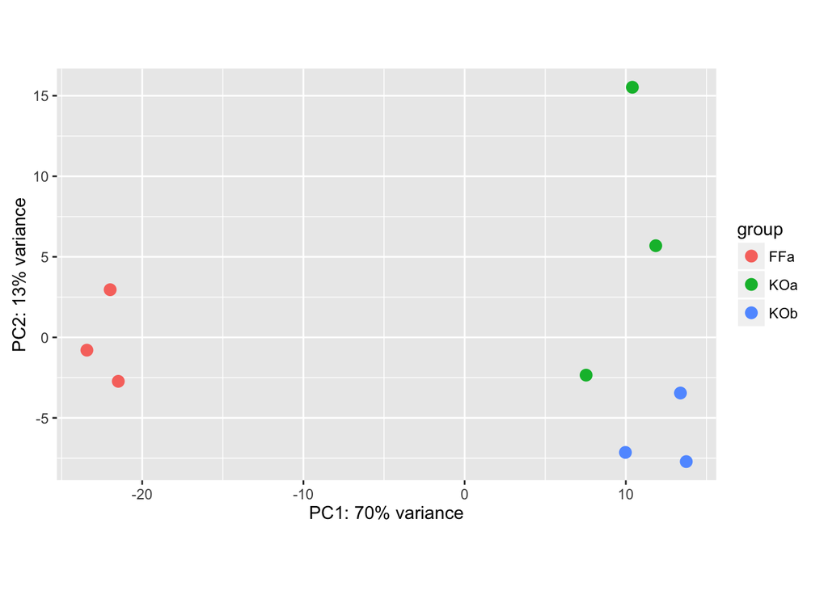

```r
rld<-rlog(dds)

plotPCA(rld, intgroup="condition")
```

Now you have the count table as deseqdataset, you can start to perform the DE analysis.

7. 1. Find the number of genes that are changed in knockdown samples versus control, i.e. KOa vs FFa and KOb vs FFa, at FDR 0.05 irrespective of fold change.
2. Find the number of genes that are changed in the above situation with fold change threshold, i.e. fold change ratio > 2.

```r
dds<-DESeq(dds)
## estimating size factors
## estimating dispersions
## gene-wise dispersion estimates
## mean-dispersion relationship
## final dispersion estimates
## fitting model and testing

# shows how many genes were differentially expressed in KOa vs FFa, with FDR<0.05
res1<-results(dds, contrast=c("condition","KOa","FFa"))
summary(res1,alpha=0.05)
##
## out of 24695 with nonzero total read count
## adjusted p-value < 0.05
## LFC > 0 (up)     : 789, 3.2%
## LFC < 0 (down)   : 1007, 4.1%
## outliers [1]     : 0, 0%
## low counts [2]   : 8112, 33%
## (mean count < 12)
## [1] see 'cooksCutoff' argument of ?results
## [2] see 'independentFiltering' argument of ?results

# shows how many genes were differentially expressed in KOa vs FFa, with FDR<0.05 and fold change ratio > 2
DE_res1<- res1[complete.cases(res1$padj),]
DE_res1<- DE_res1[DE_res1$padj<0.05 & abs(DE_res1$log2FoldChange)>1,]

# shows how many genes were differentially expressed in KOb vs FFa, with FDR<0.05
res2<-results(dds, contrast=c("condition","KOb","FFa"))

# shows how many genes were differentially expressed in KOa vs FFa, with FDR<0.05 and fold change ratio > 2
DE_res2<- res2[complete.cases(res2$padj),]
DE_res2<- DE_res2[DE_res2$padj<0.05 & abs(DE_res2$log2FoldChange)>1,]
```

[output not shown]

8. Using likelihood ratio test instead of the wald test,
1. Find the number of genes that are changed because of condition at FDR 0.05 irrespective of fold change.
2. Find the number of genes that are changed because of batch at FDR 0.05 irrespective of fold change.

```r
ddsLRT<-DESeqDataSetFromMatrix(countData=AllCounts,colData=cData,design=~batch+condition)

# LRT analysis for the condition effect
ddsLRT_con <- DESeq(ddsLRT, test="LRT", full=~batch+condition, reduced=~batch)
## estimating size factors
## estimating dispersions
## gene-wise dispersion estimates
## mean-dispersion relationship
## final dispersion estimates
## fitting model and testing

resddsLRT_con<-results(ddsLRT_con)

summary(resddsLRT_con,alpha=0.05)
##
## out of 24695 with nonzero total read count
## adjusted p-value < 0.05
## LFC > 0 (up)     : 1546, 6.3%
## LFC < 0 (down)   : 1520, 6.2%
## outliers [1]     : 0, 0%
## low counts [2]   : 9066, 37%
## (mean count < 15)
## [1] see 'cooksCutoff' argument of ?results
## [2] see 'independentFiltering' argument of ?results

resLRTorder<-resddsLRT_con[order(resddsLRT_con$padj),]
```

9. Perform multi factor analysis by adding batch as factor to design.

```r
# LRT analysis for the batch effect


ddsLRT_batch <- DESeq(ddsLRT, test="LRT", full=~batch+condition, reduced=~condition)
## estimating size factors
## estimating dispersions
## gene-wise dispersion estimates
## mean-dispersion relationship
## final dispersion estimates
## fitting model and testing

resddsLRT_batch<-results(ddsLRT_batch)

summary(resddsLRT_batch,alpha=0.05)
##
## out of 24695 with nonzero total read count
## adjusted p-value < 0.05
## LFC > 0 (up)     : 25, 0.1%
## LFC < 0 (down)   : 30, 0.12%
## outliers [1]     : 0, 0%
## low counts [2]   : 6680, 27%
## (mean count < 8)
## [1] see 'cooksCutoff' argument of ?results
## [2] see 'independentFiltering' argument of ?results
```

1. Find out number of genes that are changed because of batch as opposed to because of Group.
10. Using the genes that are changed because of condition at FDR 0.05 irrespective of fold change as our differentially expressed genes, perform the Gene Ontology and Pathway Enrichment Analysis.

```r
suppressPackageStartupMessages(library(KEGG.db))
suppressPackageStartupMessages(library(goseq))

# remove the NAs

resdat<- resLRTorder[complete.cases(resLRTorder$padj),]

degenes<-as.integer(resdat$padj<0.05)
names(degenes)<-rownames(resdat)

# remove duplicate gene names
degenes<-degenes[match(unique(names(degenes)),names(degenes))]
table(degenes)
```

```
## degenes
##     0     1
## 12563  3066
```

```r
# Fitting the probability weighting function (PWF)
# note, we use Entrez Gene ID as identifiler for this exercise
# we need to choose the correct "id" for the nullp function
# more details see
?nullp

pwf=nullp(degenes,'mm9','knownGene', plot.fit=FALSE)
```

```
## Loading mm9 length data...
```

```r
# Calculate  the  over  and  under  expressed  GO categories among DE genes
go<-goseq(pwf,'mm9','knownGene', test.cats=c("GO:BP","GO:MF","KEGG"))
```

```
## Fetching GO annotations...
```

```
## For 872 genes, we could not find any categories. These genes will be excluded.
```

```
## To force their use, please run with use_genes_without_cat=TRUE (see documentation).
```

```
## This was the default behavior for version 1.15.1 and earlier.
```

```
## Calculating the p-values...
```

Change the Keggpath id to name in the goseq output

```r
# function that converts KEGG id to KEGG description
xx <- as.list(KEGGPATHID2NAME)
temp <- cbind(names(xx),unlist(xx))

addKeggTogoseq <- function(JX,temp){
  for(l in 1:nrow(JX)){
      if(JX[l,1] %in% temp[,1]){
          JX[l,"term"] <- temp[temp[,1] %in% JX[l,1],2]
          JX[l,"ontology"] <- "KEGG"
      }
  }
  return(JX)
}

restemp<-addKeggTogoseq(go,temp)

head(restemp)
```

```
##         category over_represented_pvalue under_represented_pvalue
## 1079  GO:0002376            1.676427e-21                        1
## 10700 GO:0044822            3.732143e-19                        1
## 1648  GO:0003723            2.128020e-16                        1
## 11449 GO:0046649            2.658642e-15                        1
## 1245  GO:0002682            5.189015e-15                        1
## 714   GO:0001775            3.939722e-14                        1
##       numDEInCat numInCat                                term ontology
## 1079         497     1704               immune system process       BP
## 10700        347     1094                 poly(A) RNA binding       MF
## 1648         423     1447                         RNA binding       MF
## 11449        176      514               lymphocyte activation       BP
## 1245         287      939 regulation of immune system process       BP
## 714          219      696                     cell activation       BP
```

```r
# save the goseq result
write.csv(restemp,file="Exercise_ShortRNAseq_GO_Kegg_Wallenius.csv", row.names=F)
```